# The Relationship Between Gun Background Checks and Gun Death Rates

## by Nesly Cesar

### Objective:

Investigate the correlation between the frequency of gun background checks conducted in different states and the rate of gun-related deaths over time.

### Key Questions:

1. **Temporal Analysis:** How have the patterns of gun background checks and gun death rates changed from 1999 to 2019?
2. **Geographical Analysis:** Are there specific states or regions with higher correlations between background check volumes and gun death rates?
3. **Demographic Factors:** How do population demographics and density influence the rate of gun background checks and gun deaths?
4. **Policy Impact:** How have state-specific gun control laws impacted the relationship between background checks and gun deaths?

### Potential Impact:

Understanding the relationship between gun background checks and gun deaths can inform policymakers and stakeholders on the effectiveness of current measures and potential areas for intervention to reduce gun-related fatalities.

### Methodology:

1. **Data Preprocessing:** Clean and preprocess the datasets to handle missing values and align them for temporal and geographical analysis.
2. **Correlation Analysis:** Perform statistical analysis to evaluate the correlation between background checks and gun death rates, adjusting for population size.
3. **Trend Analysis:** Use time series analysis to identify trends and patterns over the years.
4. **Geospatial Analysis:** Utilize geographical data to map the trends and identify hotspots.
5. **Policy Evaluation:** Analyze the impact of specific gun control measures implemented in different states.

### Tools Used

- Python pandas for data manipulation and analysis.
- GeoPandas and shapely for geospatial analysis.
- Matplotlib for generating plots.

## Data preprocessing

### Cleaning and Preprocessing:

- The datasets underwent cleaning procedures, where missing data, particularly in age-adjusted death rates, were addressed by calculating midpoints of the confidence intervals. This approach minimized the impact of missing data on the analysis.
- Both datasets were aligned by state and year identifiers to ensure consistency. This involved merging the datasets on common columns and ensuring that state names and abbreviations matched. This also ensures accuracy in the analysis.
- Per capita metrics and age-adjusted rates were calculated to standardize the analysis across varying population sizes.

### Data Quality and Tidiness Issues:

- The datasets initially contained various redundant columns and inconsistencies in state naming conventions (e.g., "New-York State" vs. "New York"). These were resolved by standardizing names and removing unnecessary columns.
- Also, columns were assigned their appropriate data types to ensure and aid proper analysis.

## Analysis

**Statistical Analysis:** Descriptive statistics to understand the data distribution.

**Correlation Analysis:** Evaluate the correlation between the number of background checks per capita and gun death rates.

**Trend Analysis:** Analyze trends over time for both background checks and gun deaths.

**Geospatial Analysis:** Identify any regional patterns or hotspots.s.

### Correlation analysis between checks per capita and gun death rates

The correlation analysis shows a moderate positive correlation of approximately 0.54 between background checks per capita and the age-adjusted gun death rate. This suggests that as the number of background checks per capita increases, there tends to be an increase in the gun death rate. However, this correlation is not strong enough to imply causation, and further analysis is required to understand the underlying factors.

|  | checks_per_capita |
| --- | --- |
| checks_per_capita | 1.000000 |
| Age Adjusted Rate | 0.538879 |

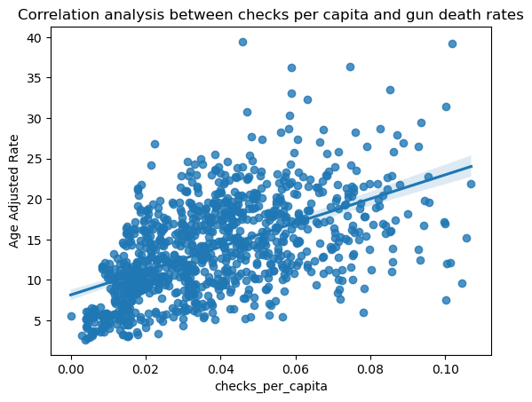

### Trend analysis to observe how background checks and gun deaths have evolved over time

**Background Checks per Capita:** There is an upward trend in background checks per capita over the years, with noticeable increases around 2013 and 2016, possibly reflecting responses to political events or mass shootings that often lead to heightened concerns about gun regulations.

**Age-Adjusted Death Rate:** The age-adjusted gun death rate shows a more stable trend, with slight fluctuations but a general increase in recent years.

The trends suggest that while background checks have increased significantly over time, the gun death rate has not decreased correspondingly, indicating other factors might be influencing the rate of gun deaths.  
Also, the two lines do not appear to mirror each other perfectly, indicating that while there is some correlation, it's not a straightforward relationship.

The parallel increase suggests that background checks alone may not sufficiently curb gun violence. Comprehensive strategies involving prevention, intervention, and community engagement might be necessary to address the root causes.

Understanding these trends can help inform public discussions on gun control policies and their potential impacts.

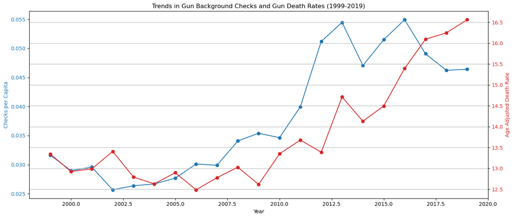

## Average checks per capita and death rates across states.

**Observations from the Plot:**

- Variability Across States: The plot shows considerable variability in both checks per capita and age-adjusted death rates across states. This highlights regional differences in gun-related activities and outcomes, and also the importance of considering local factors and policies that might influence both gun purchases and gun violence.
- Background Checks Per Capita (Blue Bars): Some states exhibit notably high rates of background checks per capita, suggesting a higher level of engagement or interest in firearm transactions in these regions.
- Age-Adjusted Death Rate (Red Line): States such as Arkansas and Alabama show higher age-adjusted death rates, suggesting that gun violence is more prevalent in these areas despite the number of background checks.
- Correlation with Death Rates: The age-adjusted death rates appear to follow a different trend compared to checks per capita. Some states with high checks per capita do not necessarily have high death rates, underscoring that checks alone may not predict gun-related fatalities.
- Insight into Policy and Enforcement: These differences could be influenced by state-specific laws, cultural attitudes towards firearms, and the effectiveness of background check systems and other preventive measures. States with high death rates might need to explore additional measures beyond background checks to effectively reduce gun violence, such as community-based interventions and education programs.

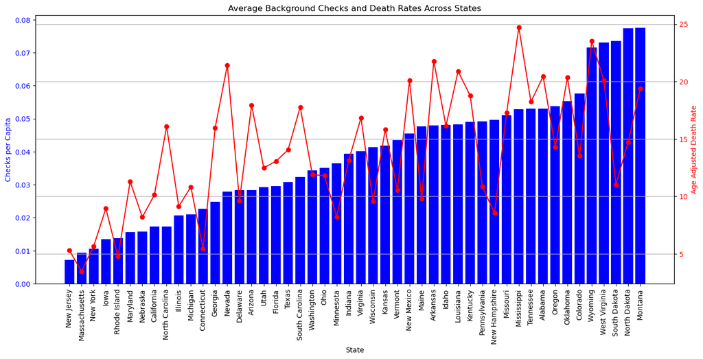

## Year-Wise Summary Plot:

1. **Checks Per Capita (Blue Line):**
   - **General Increase:** There is a noticeable increase in checks per capita over the years, particularly after 2012. This trend reflects a growing number of background checks relative to the population, possibly due to increased firearm purchases or stricter enforcement of background checks.
   - **Variability:** The standard deviation (error bars) indicates moderate variability across states, with some years showing more consistency in the data than others.
2. **Age-Adjusted Death Rate (Red Line):**
   - **Fluctuating but Increasing:** The age-adjusted death rate exhibits fluctuations, but there is a discernible upward trend starting around 2013, peaking in the later years.
   - **Increased Variability:** The error bars suggest increased variability in death rates across states, particularly in the latter years. This could reflect differing state-level factors impacting gun violence.

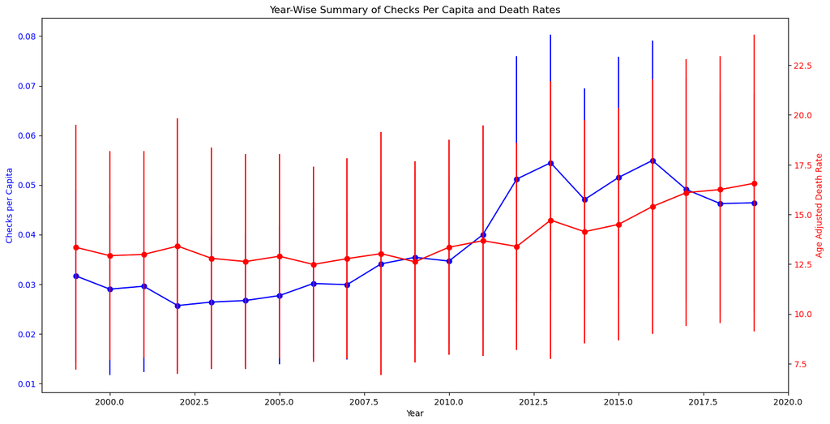

## Geospatial Analysis to identify any regional patterns

**Gun Background Checks Per Capita (2019):**

- The map shows a varied distribution of background checks per capita across states, with darker shades (higher values) appearing predominantly in the Midwest and parts of the West. While lighter shades, predominantly seen in some Southern and Northeastern states, represent lower rates of background checks per capita. This suggests regional variations in the frequency of gun background checks, possibly influenced by local laws, culture, and attitudes towards gun ownership.
- Understanding these regional variations can help policymakers tailor gun control measures more effectively. States with lower checks per capita may need increased monitoring or adjusted policies to ensure effective background check coverage.

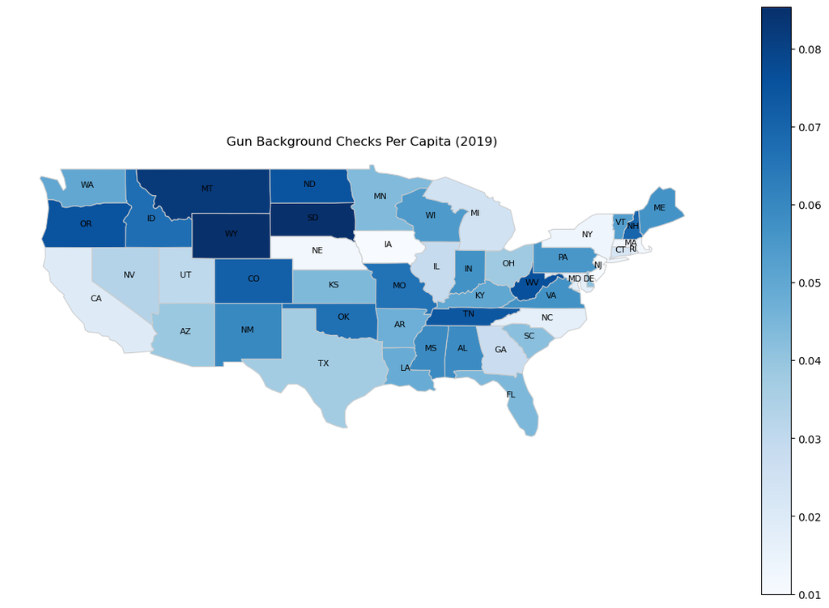

**Age-Adjusted Gun Death Rate (2019):**

- **Darker Shades:** States with darker shades of red indicate higher age-adjusted gun death rates. These states may require more focused attention to understand and mitigate the factors contributing to higher rates of gun-related fatalities.
- **Lighter Shades:** Lighter shades suggest lower gun death rates, possibly indicating effective gun control measures, lower gun ownership, or other socio-economic factors that contribute to fewer gun-related deaths.

**Insights:**

- **Non-Linear Relationship:** The lack of a clear correlation in geographic patterns between the two maps suggests that the relationship between background check rates and gun death rates is complex and likely influenced by a multitude of factors.

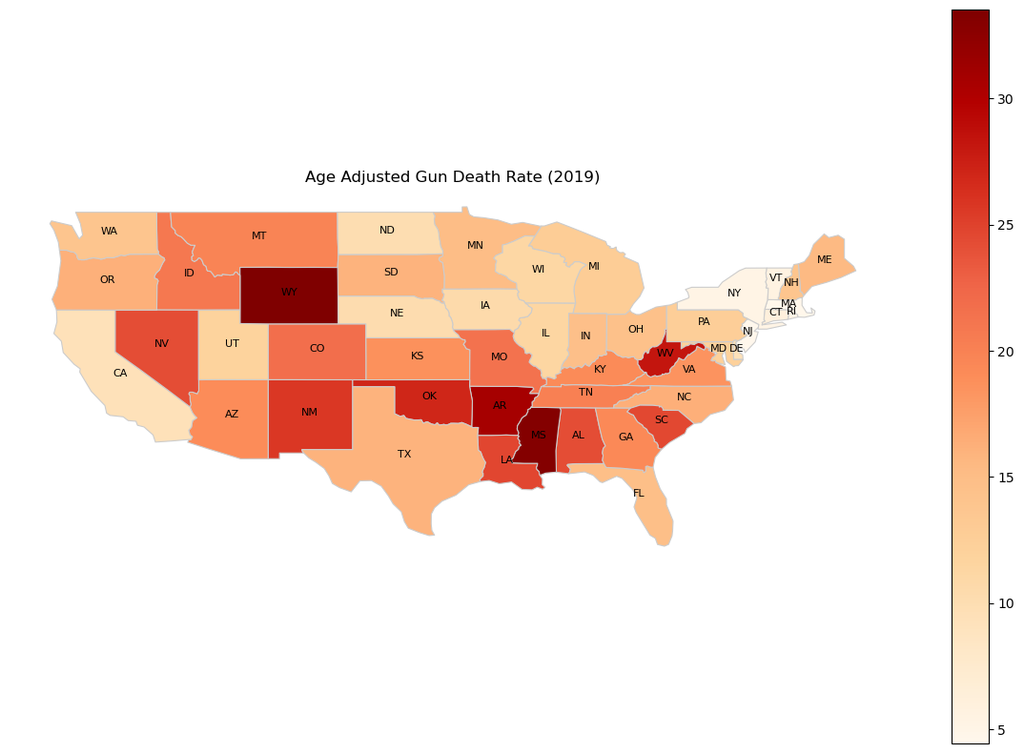

## Discussion and Conclusion

### Key Findings

**Data Quality and Tidiness Issues:**

- **State Naming Inconsistencies:** Resolved through standardization but highlighted challenges in merging datasets.
- **Handling Missing Data:** Imputed values for missing age-adjusted death rates, emphasizing the need for complete data.

**Correlation Between Background Checks and Gun Death Rates:**

- Moderate positive correlation suggests background checks alone may not reduce gun fatalities; other factors are significant.

**High Death Rates Despite High Background Checks:**

- States like Montana and Mississippi showed high death rates even with extensive background checks, indicating the need for broader strategies.

### Recommendations

**Targeted Gun Control:**

- Implement stricter measures in high-risk states like Mississippi.

**Comprehensive Strategies:**

- Go beyond background checks to include education, economic development, and mental health support.

**Further Research:**

- Investigate the correlation between background checks and death rates and improve data collection.

**Public Awareness:**

- Focus on community outreach in high-risk areas to educate about gun safety.

## Conclusion

- Gun violence is complex, and background checks alone are insufficient.
- Regional disparities require tailored approaches.
- Continued research and informed policy-making are essential for reducing gun-related fatalities.